# Practical Machine Learning Assignment

##### *November, 2014*

#### Introduction

This paper presents the development of a machine learning algorithm that predicts how well a subject performs certain exercises by looking at various metrics from a set of activity monitors.

#### Data

The data for this project comes from the study *Accelerometers’ Data Classification of Body Postures and Movements*. According to the study’s paper, “Six young health participants were asked to perform one set of 10 repetitions of the Unilateral Dumbbell Biceps Curl in five different fashions: exactly according to the specification (Class A), throwing the elbows to the front (Class B), lifting the dumbbell only halfway (Class C), lowering the dumbbell only halfway (Class D) and throwing the hips to the front (Class E).” The data is housed at this [web portal](http://groupware.les.inf.puc-rio.br/har;%202014-11-14).

#### Tools

The model was built in [R](http://www.r-project.org/)/[R Studio](http://www.rstudio.com/) by using functions from the *caret* and *randomForest* [CRAN](http://cran.r-project.org/) packages.

#### Model Build

Both the train/test splitting function and the random forest algorithm use random numbers as input. To ensure reproducibility of this code’s output, the random seed is set. The two libraries are then called. *Note: each of these packages must be installed prior to running this code.*

```r
set.seed(4444)
library(caret)
library(randomForest)
```

The two datasets are then downloaded from the web portal and saved to a local drive. Once there, the two datasets are then read into the R environment as objects.

```r
trainingURL <- "https://d396qusza40orc.cloudfront.net/predmachlearn/pml-training.csv"
testingURL <- "https://d396qusza40orc.cloudfront.net/predmachlearn/pml-testing.csv"

if(!file.exists("pml-training.csv")){download.file(url=trainingURL,destfile="pml-training.csv")}
if(!file.exists("pml-testing.csv")){download.file(url=testingURL,destfile="pml-testing.csv")}

training <- read.csv(file="pml-training.csv",header=TRUE,stringsAsFactors=FALSE)
testing <- read.csv(file="pml-testing.csv",header=TRUE,stringsAsFactors=FALSE)
```

The quality of each exercise in the training dataset is recorded as a letter from A to E. The load process did not have instructions that these represent classifications, so this attribute is converted to an unordered factor. Many of the quantitative attributes are sparsely populated and/or represent derived/summarized fields from other attributes. To overcome these issues, the less essential attributes are filtered out for modeling purposes. The remaining quantitative attributes are then converted to the numeric datatype for consistency.

```r
training$classe <- as.factor(training$classe)

atts <- c(7:11,37:49,60:68,84:86,113:124,140,151:159)

for(i in atts){
  training[,i] <- as.numeric(training[,i])
  testing[,i] <- as.numeric(testing[,i])
}
```

Even though training and testing datasets are given, it can be useful to split the former into its own train/test sets since the latter has only twenty few observations. This further splitting at a 70/30 ratio.

```r
inTrain <- createDataPartition(y=training$classe,p=0.7,list=FALSE)
train <- training[inTrain,]
test <- training[-inTrain,]
```

Now that each of the sub-datasets are in good order, the model can be selected and executed. Several classification models were considered for this project. Since there are many attributes that are quite technical in their meaning, the thought is that trying to get a good model that is transparent and easy to understand would be likely impossible. With those aspects no longer needed, a model with a high likelihood of accuracy is an ensemble method known as “random forest.” This model often is used in successful [Kaggle](https://www.kaggle.com/) competitions and is well-supported in R. *Note: the model takes approximately one hour to run on a standard laptop, so the finished model is loaded in this markdown file.*

```r
if(file.exists("rfModel.Rda")){
  load("rfModel.Rda")} else {
    modFit <- train(classe~.,method="rf",data=train[,c(atts,160)])
    }
```

```r
modFit
```

```
## Random Forest
##
## 13737 samples
##    52 predictor
##     5 classes: 'A', 'B', 'C', 'D', 'E'
##
## No pre-processing
## Resampling: Bootstrapped (25 reps)
##
## Summary of sample sizes: 13737, 13737, 13737, 13737, 13737, 13737, ...
##
## Resampling results across tuning parameters:
##
##   mtry  Accuracy  Kappa  Accuracy SD  Kappa SD
##    2    0.992     0.990  0.00134      0.00169
##   27    0.995     0.994  0.00117      0.00148
##   52    0.990     0.987  0.00310      0.00393
##
## Accuracy was used to select the optimal model using  the largest value.
## The final value used for the model was mtry = 27.
```

```r
modFit$finalModel
```

```
##
## Call:
##  randomForest(x = x, y = y, mtry = param$mtry)
##                Type of random forest: classification
##                      Number of trees: 500
## No. of variables tried at each split: 27
##
##         OOB estimate of  error rate: 0.25%
## Confusion matrix:
##      A    B    C    D    E  class.error
## A 3904    1    0    0    1 0.0005120328
## B    4 2651    3    0    0 0.0026335591
## C    0    4 2391    1    0 0.0020868114
## D    0    0   14 2237    1 0.0066607460
## E    0    1    0    4 2520 0.0019801980
```

```r
testConf <- table(test$classe,predict(modFit,test))
confusionMatrix(testConf)
```

```
## Confusion Matrix and Statistics
##
##
##        A    B    C    D    E
##   A 1674    0    0    0    0
##   B    3 1136    0    0    0
##   C    0    1 1025    0    0
##   D    0    0    1  963    0
##   E    0    0    0    0 1082
##
## Overall Statistics
##
##                Accuracy : 0.9992
##                  95% CI : (0.998, 0.9997)
##     No Information Rate : 0.285
##     P-Value [Acc > NIR] : < 2.2e-16
##
##                   Kappa : 0.9989
##  Mcnemar's Test P-Value : NA
##
## Statistics by Class:
##
##                      Class: A Class: B Class: C Class: D Class: E
## Sensitivity            0.9982   0.9991   0.9990   1.0000   1.0000
## Specificity            1.0000   0.9994   0.9998   0.9998   1.0000
## Pos Pred Value         1.0000   0.9974   0.9990   0.9990   1.0000
## Neg Pred Value         0.9993   0.9998   0.9998   1.0000   1.0000
## Prevalence             0.2850   0.1932   0.1743   0.1636   0.1839
## Detection Rate         0.2845   0.1930   0.1742   0.1636   0.1839
## Detection Prevalence   0.2845   0.1935   0.1743   0.1638   0.1839
## Balanced Accuracy      0.9991   0.9992   0.9994   0.9999   1.0000
```

The accuracy rate is so high that a confusion matrix expressed as a heatmap appears to be perfect.

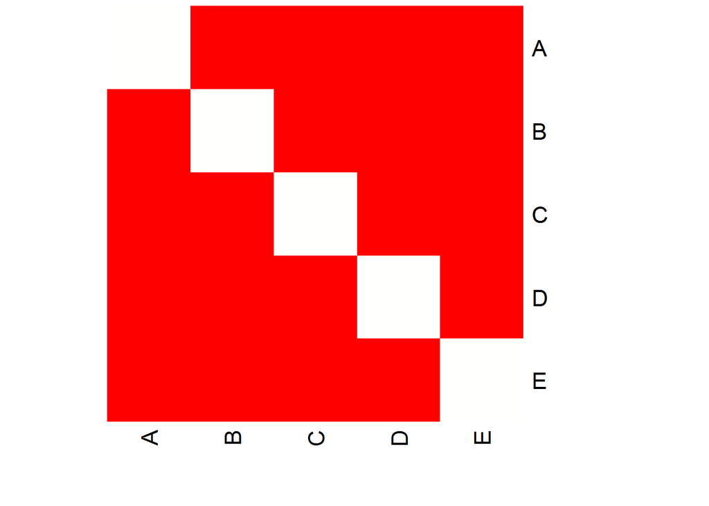

### Conclusion

In summary, the datasets provided contained so many available attributes and so many observations that obtaining a successful model was nearly inevitable. The hurdle rate for accuracy was about 28% because one could naively predict class A (exercise done correctly) and be correct about 28% of the time. Thus, this model should be considered highly predictive and useful for this application or similar ones.

##### References:

*1 Ugulino, W.; Cardador, D.; Vega, K.; Velloso, E.; Milidiu, R.; Fuks, H. Wearable Computing: Accelerometers’ Data Classification of Body Postures and Movements. Proceedings of 21st Brazilian Symposium on Artificial Intelligence. Advances in Artificial Intelligence - SBIA 2012. In: Lecture Notes in Computer Science. , pp. 52-61. Curitiba, PR: Springer Berlin / Heidelberg, 2012. ISBN 978-3-642-34458-9. DOI: 10.1007/978-3-642-34459-6_6.

2 http://groupware.les.inf.puc-rio.br/har#ixzz3JFOHOQyg* Extracted November 14, 2014